# AS3-2: 股市動態

### Section-3 Visualizing Stock Dynamics 1995-2005

**§ 3.1** Which stock fell the most right after the technology bubble burst in March 2000?

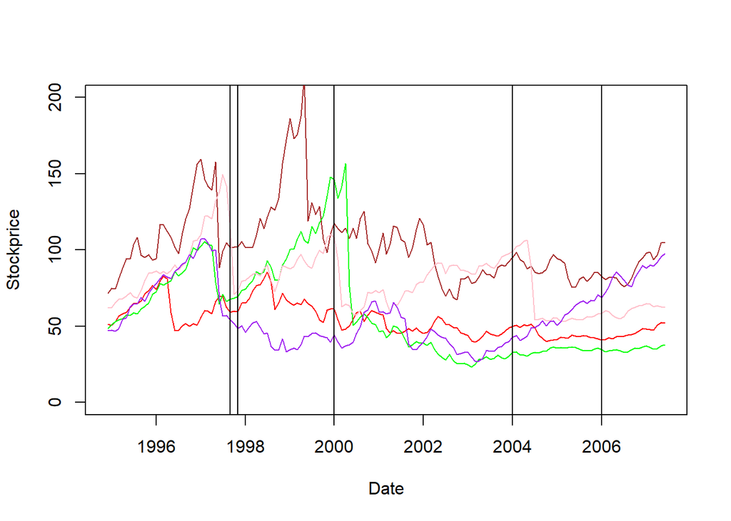

```r
#Answer：GE

#使用plot()函數來繪製，加上一個 type參數為1，使之繪製成折線圖.
#命名x與y軸，並設定y軸為0至200之區間
plot(CocaCola$Date[300:450], CocaCola$StockPrice[300:450], type="l",
col="red",ylim=c(0,200),xlab = "Date",ylab="Stockprice") #紅線為CocaCola公司
lines(IBM$Date[300:450], IBM$StockPrice[300:450],col="brown") #咖啡線為IBM公司
lines(GE$Date[300:450], GE$StockPrice[300:450],col="Green") #綠線為GE公司
lines(ProcterGamble$Date[300:450], ProcterGamble$StockPrice[300:450],col="pink") #粉線為ProcterGamble公司
lines(Boeing$Date[300:450], Boeing$StockPrice[300:450],col="Purple") #紫線為Boeing公司

#用abline() 函數繪製輔助線,下例為v=as.Date(c("要加入輔助線之時間"))，設定線寬為1
abline(v=as.Date(c("2000-01-01")), lwd=1)
abline(v=as.Date(c("1997-09-01")), lwd=1)
abline(v=as.Date(c("1997-11-01")), lwd=1)
abline(v=as.Date(c("2004-01-01")), lwd=1)
abline(v=as.Date(c("2006-01-01")), lwd=1)
```

```r
#此題可得在2000年間,GE公司股值下跌最多
```

**§ 3.2** Which stock reaches the highest value in the time period 1995-2005?

```r
#Answer：IBM
#由3.1圖可得在1995-2005年間,IBM公司股值達到最高值
```

**§ 3.3** In October of 1997, there was a global stock market crash that was caused by an economic crisis in Asia. Comparing September 1997 to November 1997, which companies saw a decreasing trend in their stock price? (Select all that apply.)

```r
#Answer：Procter and Gamble
#Answer：Boeing

#由3.1圖可得在1997九月到十一月間,Procter and Gamble跟Boeing公司都有股價下降的趨勢
```

**§ 3.4** In the last two years of this time period (2004 and 2005) which stock seems to be performing the best, in terms of increasing stock price?

```r
#Answer：Boeing
#由3.1圖可得在2004與2005之間,就股價上漲趨勢而言,Boeing公司表現最佳
```

### Section-4 Monthly Trends

**§ 4.1** For IBM, compare the monthly averages to the overall average stock price. In which months has IBM historically had a higher stock price (on average)? Select all that apply.

```r
#mean=144.4
#Answer：January,February,March,April,May

tapply(IBM$StockPrice,months(IBM$Date),mean)
```

```
  一月   七月   九月   二月   八月 十一月 十二月   十月   三月   五月   六月   四月
 150.2  139.1  139.1  152.7  140.1  138.0  140.8  137.3  152.4  151.5  139.1  152.1
```

```r
#使用tapply()看不同月份中,其平均的股價
summary(IBM$StockPrice) #看ibm公司的股價統計值,找出高於平均的月份
```

```
   Min. 1st Qu.  Median    Mean 3rd Qu.    Max.
   43.4    88.3   112.1   144.4   165.4   438.9
```

**§ 4.2** General Electric and Coca-Cola both have their highest average stock price in the same month. Which month is this?

```r
#Answer：April

#GE
which.max(tapply(GE$StockPrice,months(GE$Date),mean))
```

```
四月
  12
```

```r
#使用tapply()看不同月份中,GE平均的股價,接著使用which.max()求出最大值在幾月

#CocaCol
which.max(tapply(CocaCola$StockPrice,months(CocaCola$Date),mean))
```

```
四月
  12
```

```r
#使用tapply()看不同月份中,CocaCola平均的股價,接著使用which.max()求出最大值在幾月

#最後得兩間公司股價最大值都在四月
```

**§ 4.3** For the months of December and January, every company’s average stock is higher in one month and lower in the other. In which month are the stock prices lower?

```r
# Answer：December is lower

#GE
GE1=tapply(GE$StockPrice,months(GE$Date),mean)[1]#一月在第一欄
GE12=tapply(GE$StockPrice,months(GE$Date),mean)[7]#十二月在第七欄
#使用tapply()看1月及12月份中,GE平均的股價,
GE1>GE12 #檢驗其大小
```

```
一月
TRUE
```

```r
#CocaCola
CocaCola1=tapply(CocaCola$StockPrice,months(CocaCola$Date),mean)[1]
CocaCola12=tapply(CocaCola$StockPrice,months(CocaCola$Date),mean)[7]
#使用tapply()看1月及12月份中,CocaCola平均的股價
CocaCola1>CocaCola12#檢驗其大小
```

```
一月
TRUE
```

```r
#ProcterGamble
ProcterGamble1=tapply(ProcterGamble$StockPrice,months(ProcterGamble$Date),mean)[1]
ProcterGamble12=tapply(ProcterGamble$StockPrice,months(ProcterGamble$Date),mean)[7]
#使用tapply()看1月及12月份中,ProcterGamble平均的股價
ProcterGamble1>ProcterGamble12#檢驗其大小
```

```
一月
TRUE
```

```r
#Boeing
Boeing1=tapply(Boeing$StockPrice,months(Boeing$Date),mean)[1]
Boeing12=tapply(Boeing$StockPrice,months(Boeing$Date),mean)[7]
#使用tapply()看1月及12月份中,Boeing平均的股價
Boeing1>Boeing12#檢驗其大小
```

```
一月
TRUE
```

```r
#IBM
IBM1=tapply(IBM$StockPrice,months(IBM$Date),mean)[1]
IBM12=tapply(IBM$StockPrice,months(IBM$Date),mean)[7]
#使用tapply()看1月及12月份中,IBM平均的股價
IBM1>IBM12#檢驗其大小
```

```
一月
TRUE
```

```r
#可得每個公司的股價上,一月份大於十二月份為TRUE,因此12月的股價較低
```